# Relación de las actividades extracurriculares en el desarrollo personal de los estudiantes de la UTEC en el ciclo 2023-1

# 1 Introducción

## 1.1 Relevancia

**Motivación:**

La motivación en esta investiagcaión es la comprensión del valor de las actividades extracurriculares en el desarrollo personal de los estudiantes de la UTEC en el ciclo 2023-1. Nos planteamos preguntas fundamentales: ¿Cómo influyen estas actividades en el crecimiento integral de los estudiantes? ¿Cuál es la relación entre la participación en actividades extracurriculares y el rendimiento académico? ¿En qué medida estas actividades contribuyen al desarrollo de habilidades blandas? ¿La realción que presentan es negativa o positiva?

–

**Importancia:**

La importancia de este estudio radica en su relevancia social y laboral. En un mundo cada vez más competitivo, es fundamental que los estudiantes universitarios desarrollen tanto conocimientos teóricos como habilidades sociales como el liderazgo, el trabajo en equipo y la comunicación efectiva. Entender cómo las actividades extracurriculares pueden contribuir a estos aspectos permite establecer políticas educativas más sólidas y eficientes, preparando a los estudiantes de la UTEC para enfrentar los desafíos del mundo laboral y contribuir significativamente a la sociedad.

## 1.2 Objetivo

Para los siguientes objetivos, se planteo el objetivo principal de analizar la influencia de las actividades extracurriculares en el desarrollo personal de los estudiantes de la UTEC durante el ciclo 2023-1.

- **Objetivo 1:** Analizar la relación entre la participación en actividades extracurriculares y la autopercepción de desarrollo personal de los estudiantes de la UTEC en el ciclo 2023-1.
- **Objetivo 2:** Analizar la relación entre la participación en actividades extracurriculares y el rendimiento académico de los estudiantes de la UTEC en el ciclo 2023-1.
- **Objetivo 3:** Analizar la relación de las actividades extracurriculares con el desarrollo de habilidades blandas de los estudiantes de la UTEC en el ciclo 2023-1.

## 1.3 Contexto

Para comprender adecuadamente el tema propuesto, es necesario tener en cuenta el siguiente conocimiento relacionado:

- **Actividades extracurriculares:** Se refiere a las actividades que se realizan externo al plan de estudios regular y tienen como objetivo complementar el aprendizaje y el desarrollo personal de los estudiantes. Esto puede incluir la participación en deportes, clubes, voluntariado, eventos culturales, trabajo, etc.
- **Desarrollo personal:** El desarrollo personal abarca el desarrollo y la mejora de las habilidades duras y blandas, conocimientos, actitudes y valores de una persona. Este desarrollo es esencial en la educación superior para enfrentar desafíos académicos y profesionales.

# 2 Análisis descriptivo

## 2.1 Objetivo 1

**Relación entre la participación en actividades extracurriculares y la autopercepción**

**Relación de Cantidad de actividades y Satisfacción**

Se analiza la releación entre la cantidad de actividades que realiza un estudiante y su satisfacción con su participación en actividades extracurriculares. Como se analiza una variable cualitativa y una variable cunatitativa discreta con pocos valores se usará un gráfico de mosaico para observar la relación.

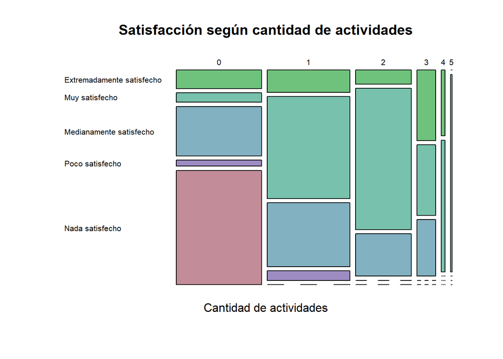

Al observar la gráfica se puede destacar dos aspectos. En primer lugar gran parte de los que no realizan actividades están nada satisfechos con su participación, incluso son los únicos en esta categoría. Por otro lado aquellos que realizan más de una actividad extracurricular no se encuentran poco o nada satisfechos con su participación, incluso indican estar extremadamente o muy satisfecho más seguido que aquellos que realizan 1 o 0.

Con esto podemos concluir que mientras más actividades realize alguien mayor será su satisfacción en su participación en actividades.

## 2.2 Objetivo 2

**Relación entre la participación en actividades extracurriculares y el rendimiento académico**

**Hora de dedicadas a clases vs horas dedicadas a actividades a la semana**

Otro aspecto a comparar es si la cantidad de horas que se dedican a las actividades afecta a la cantiad de horas que se dedican a clases. Para esto se compararán las variables Horas de estudio y Horas Actividades. Ambas son variables cuantitativas que pueden ser comparadas mediante un gráfico de dispersión y su correlación.

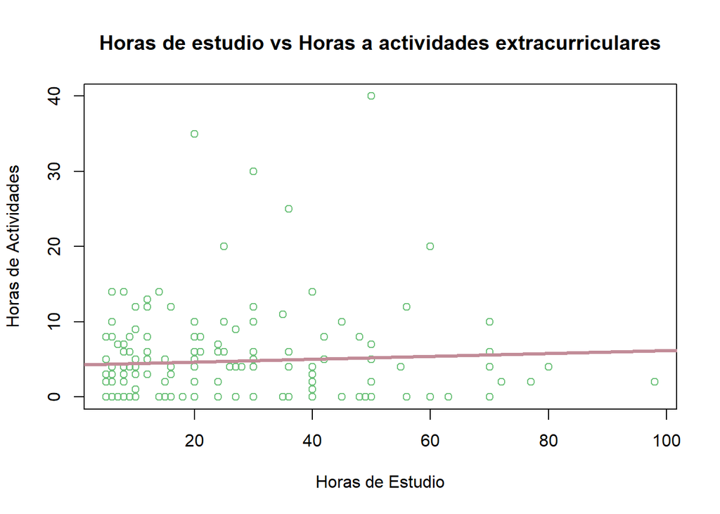

```
## [1] "Correlación: 0.06"
```

Al comparar la cantidad de horas dedicadas a los estudios vs la cantidad de horas dedicadas a las actividades se puede observar que dedicar más horas a las actividades no necesariamente significa dedicar menos horas a los estudios. En sí las variables no tienen una gran relación, lo que se puede comprobar en la correlación. En analisis de estas varaibles indican que no existe relación.

## 2.3 Objetivo 3

**Relación de las actividades extracurriculares con el desarrollo de habilidades blandas**

**Puntaje de test según participación**

En la encuesta los estudiantes realizaron un test para medir sus habilidades sociales y de liderazgo de manera más objetiva. Debido a que el test es una varaible cuantitativa se usarán descriptores numéricos y gráficos. Se utilizará la media debido a que los datos se encuentran en un rango especifico dado por el test.

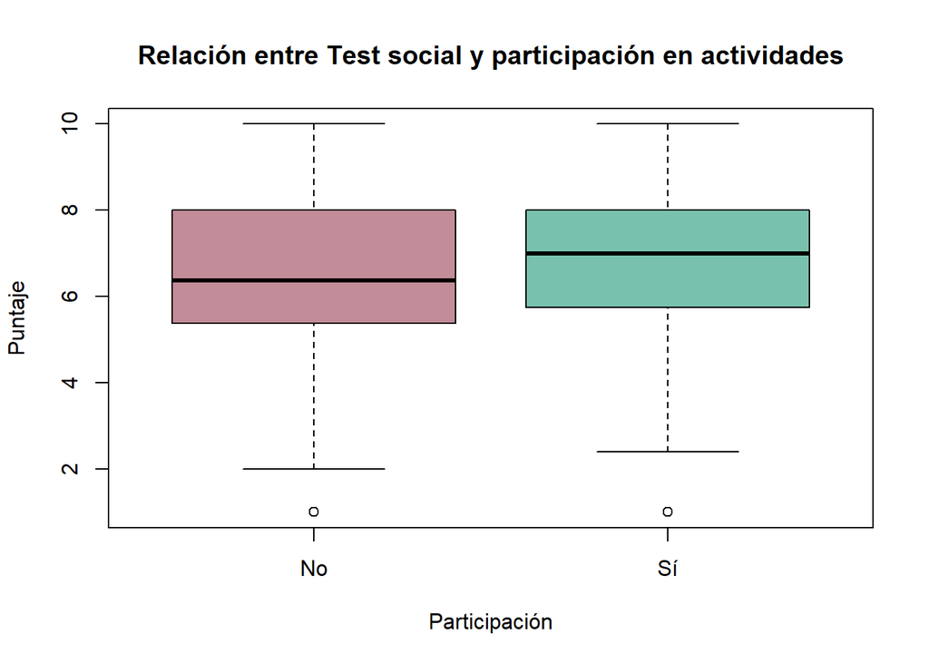

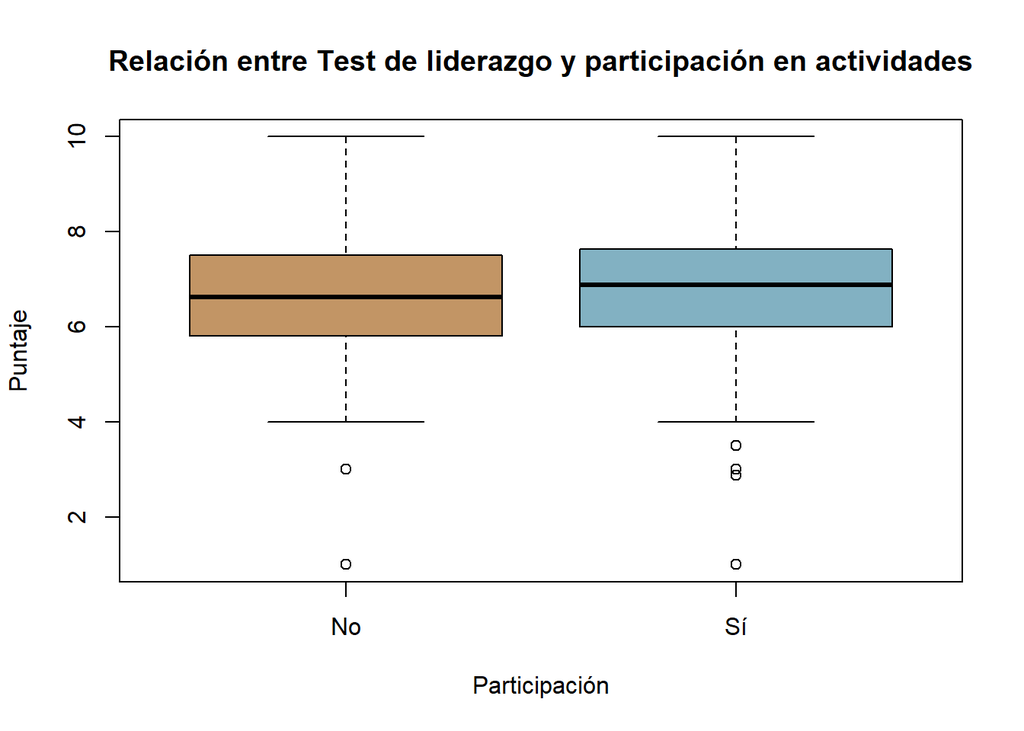

Puntaje entre quienes participan:

```
## [1] "Media del Test Social: 6.66"
```

```
## [1] "Media del Test de Liderazgo: 6.78"
```

Puntaje entre quienes no participan:

```
## [1] "Media del Test Social: 6.36"
```

```
## [1] "Media del Test de Liderazgo: 6.56"
```

# 3 Análisis probabilístico

## 3.1 Probabilidades empíricas

### 3.1.1 Variable 1

**Experimento:** Seleccionar un estudiante al azar de la UTEC en el ciclo 2023-1

**Variable:** Opinión sobre el impacto de las actividades extracurriculares en el rendimiento académico

**Eventos:**

- A: El estudiante opina que las actividades extracurriculares no afectan en el rendimiento académico
- B: El estudiante opina que las actividades extracurriculares afectan negativamente en el rendimiento académico
- C: El estudiante opina que las actividades extracurriculares afectan positivamente en el rendimiento académico

**Espacio de resultados:** E = {“No afectan” ; “Si, afectan negativamente” ; “Si, afectan positivamente”}

Definimos la función de probabilidad:

$$f(x) = P(X=x)$$

Donde calcularemos las probabilidades dividiendo la cantidad de observaciones que hay en cada evento del espacio muestral y lo dividiremos entre el total de observaciones.

```r
sum(DF$Relación_rendimiento=="No afectan.")/(nrow(DF))
```

```
## [1] 0.4784946
```

```r
sum(DF$Relación_rendimiento=="Si, afectan negativamente")/(nrow(DF))
```

```
## [1] 0.1182796
```

```r
sum(DF$Relación_rendimiento=="Si, afectan positivamente")/(nrow(DF))
```

```
## [1] 0.4032258
```

|  | No afectan | Afectan negativamente | Afectan positivamente |
| --- | --- | --- | --- |
| x | 0 | 1 | 2 |
| f(x) | 0.478 | 0.118 | 0.403 |

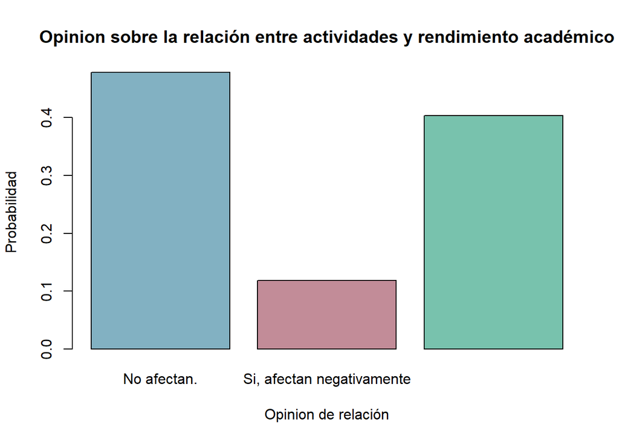

Según los resultados obtenidos, se sabe que si se pregunta a un estudiante de UTEC es muy probable que opine que las actividades extracurriculares no afectan al rendimiento académico (0.478) o que afecten positivamente (0.403)

### 3.1.2 Variable 2

**Experimento:** Seleccionar un estudiante al azar de la UTEC en el ciclo 2023-1

**Variable:** Opinión sobre el impacto de las actividades extracurriculares en las habilidades sociales

**Eventos:**

- A: El estudiante opina que las actividades extracurriculares no afectan en las habilidades sociales
- B: El estudiante opina que las actividades extracurriculares afectan negativamente en las habilidades sociales
- C: El estudiante opina que las actividades extracurriculares afectan positivamente en las habilidades sociales

**Espacio de resultados:** E = {“No afectan” ; “Si, afectan negativamente” ; “Si, afectan positivamente”}

Definimos la función de probabilidad:

$$f(x) = P(X=x)$$

Donde calcularemos las probabilidades dividiendo la cantidad de observaciones que hay en cada evento del espacio muestral y lo dividiremos entre el total de observaciones.

```r
sum(DF$Relacion_habilidades=="No afectan.")/(nrow(DF))
```

```
## [1] 0.3172043
```

```r
sum(DF$Relacion_habilidades=="Si, afectan negativamente")/(nrow(DF))
```

```
## [1] 0.02688172
```

```r
sum(DF$Relacion_habilidades=="Si, afectan positivamente.")/(nrow(DF))
```

```
## [1] 0.655914
```

|  | No afectan | Afectan negativamente | Afectan positivamente |
| --- | --- | --- | --- |
| x | 0 | 1 | 2 |
| f(x) | 0.317 | 0.027 | 0.656 |

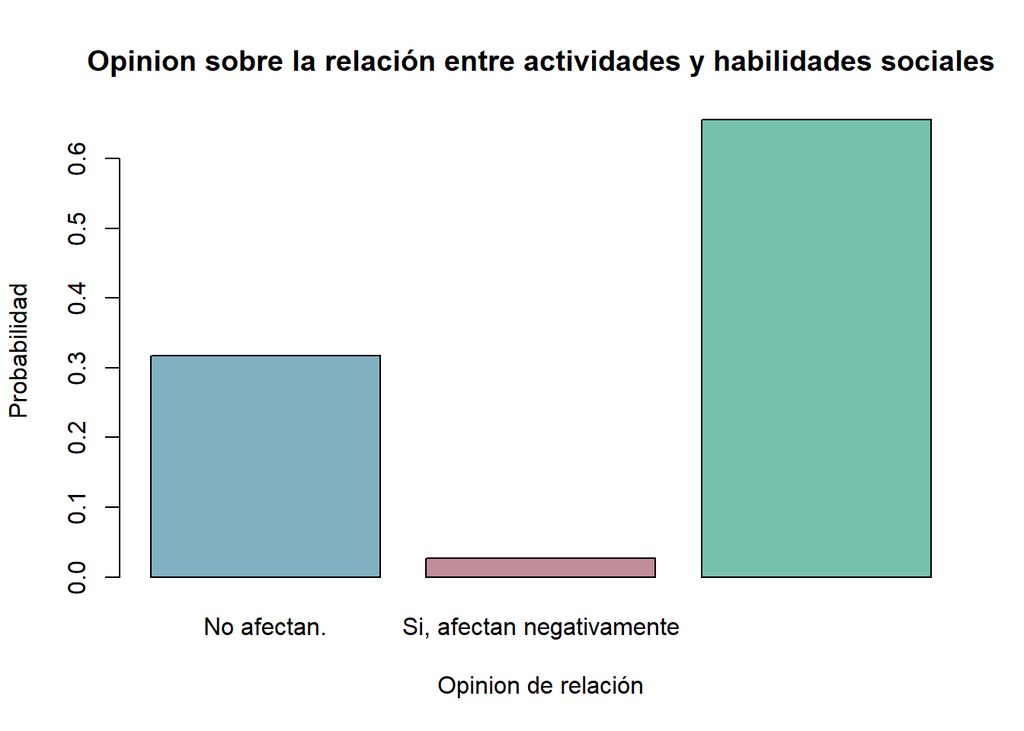

Según los resultados obtenidos, se sabe que si se pregunta a un estudiante de UTEC es muy probable que opine que las actividades extracurriculares afectan positivamente a las habilidades sociales (0.656), mientras que es muy poco probable que opine que afectan negativamente (0.027)

## 3.2 Probabilidades condicionales

### 3.2.1 Dependientes

**Variables:**

Variable 1: Cantidad de actividades extracurriculares.

Variable 2: Satisfacción con participación en actividades extracurriculares.

Experimento: Seleccionar un estudiante al azar de la UTEC en el ciclo 2023-1

**Eventos:**

A: Seleccionar estudiantes que participan en más de 1 actividad extracurricular.

B: Seleccionar estudiantes que estén poco o nada satisfechos con su participación en actividades extracurriculares.

**Espacio y distribución de resultados:**

E = {AB ; A’B ; AB’ ; A’B’}

```
##
##      A'  A
##   B' 84 60
##   B  42  0
```

#### 3.2.1.1 Probabilidad empírica

Se calcula la probabilidad de los eventos A, B y A intersección B con el método visto anteriormente.

```r
evento_A <- sum(DF$Cantidad>1)

evento_B <- sum(DF$Satisfaccion=="Poco satisfecho" | DF$Satisfaccion=="Nada satisfecho")

evento_AB <- sum(DF$Cantidad>1 & (DF$Satisfaccion=="Poco satisfecho" | DF$Satisfaccion=="Nada satisfecho"))


PA = evento_A/nrow(DF)

PB = evento_B/nrow(DF)

PAB = evento_AB/nrow(DF)
```

```
## [1] "Probabilidad del evento A: 0.3226"
```

```
## [1] "Probabilidad del evento B: 0.2258"
```

```
## [1] "Probabilidad del evento AnB: 0"
```

Análisis

- La probabilidad empírica de evento A es de 0,32, esto indica la probabilidad de que un estudiante de la UTEC participe en más de una actividad.
- La probabilidad empírica de evento B es de 0,22, esto indica la probabilidad de que un estudiante de la UTEC esté poco o nada satisfechos con su participación en actividades.
- La probabilidad de la intersección del evento A y el evento B es 0, esto indica que las variables son incompatibles y por lo tanto tienen una dependencia total.

#### 3.2.1.2 Formula de probabilidad condicional

$$\mathbb{P}(B|A)=\frac{\mathbb{P}(A \cap
B)}{\mathbb{P}(A)}$$

```
## [1] "Probabilidad de B|A: 0"
```

$$\mathbb{P}(A|B)=\frac{\mathbb{P}(A \cap
B)}{\mathbb{P}(B)}$$

```
## [1] "Probabilidad de A|B: 0"
```

Análisis

Si se considera que la probabilidad condicional define que un evento, por ejemplo, A ocurre cuando el evento B ya sucedió. Si estos eventos (A y B) son independientes la probabilidad del evento A no depende de B, por lo que la probabilidad de A será la misma de la probabilidad de A dado B.

$$\mathbb{P}(AB)=\mathbb{P}(A)\mathbb{P}(B)$$

```
## [1] "Probabilidad de BnA: 0"
```

```
## [1] "Probabilidad de B * Probabilidad de A: 0.0728"
```

$$\mathbb{P}(B|A)=\frac{\mathbb{P}(A)\mathbb{P}(B)}{\mathbb{P}(A)}$$

$$\mathbb{P}(B|A)=\mathbb{P}(B)$$

```
## [1] "Probabilidad de B|A: 0"
```

```
## [1] "Probabilidad de B: 0.2258"
```

$$\mathbb{P}(A|B)=\frac{\mathbb{P}(A)\mathbb{P}(B)}{\mathbb{P}(B)}$$

$$\mathbb{P}(A|B)=\mathbb{P}(A)$$

```
## [1] "Probabilidad de A|B: 0"
```

```
## [1] "Probabilidad de A: 0.3226"
```

En base a los resultados obtenidos, se puede concluir que los eventos A y B son completamente dependientes. No solo las igualdades para eventos independientes son diferentes si no que la intersección de ambas variables da un espacio nulo, es decir de probabilidad 0.

Estos resultados nos indican que mientras sucede un evento no puede suceder el otro. En caso de los eventos seleccionados, mientras alguién realice más de una actividad extracurricular, no estará nada ni poco satisfecho con su participación en actividades.

#### 3.2.1.3 Probabilidad total

Según este teorema la probabilidad de B se puede representar como:

$$\mathbb{P}(B)=\mathbb{P}(B∩A)+\mathbb{P}(B∩A')$$

Que con la formula de probabilidad condicional:

$$\mathbb{P}(B)=\mathbb{P}(B|A)\mathbb{P}(A)+\mathbb{P}(B|A')\mathbb{P}(A')$$

```r
PB
```

```
## [1] 0.2258065
```

```r
PAl = sum(!DF$Cantidad>1)/nrow(DF)

PAlB = sum(DF$Cantidad<=1 & (DF$Satisfaccion=="Poco satisfecho" | DF$Satisfaccion=="Nada satisfecho"))/nrow(DF)


P_B_dado_Al <- PAlB / PAl

PBx <- P_B_dado_A*PA + P_B_dado_Al*PAl

PBx
```

```
## [1] 0.2258065
```

Como se observa, tanto la probabilidad empírica de B como la probabilidad de B obtenida con probabilidad coinciden

#### 3.2.1.4 Teorema de Bayes

Este teorema nos permite encontrar la probabilidad de A dado B si es que se conoce previamente la probabilidad de B dado a A, y viceversa.

```r
P_A_dado_B
```

```
## [1] 0
```

```r
P_B_dado_A*PA/PB
```

```
## [1] 0
```

Se puede observar que la probabilidad obtenida por probabilidad condicional y teorema de bayes es la misma. Para este caso el Teorema de Bayes nos permite estimar la probabilidad de que un estudiante participe en más de 1 actividad extracurricular dado que esta poco o nada satisfecho con su participación en actividades. Para calcular esto se neceita la probabilidad de que un estudiante este poco o nada satisfecho con su participacion en actividades extracurriculares dado que participa en más de una actividad y las probabilidades de ambos eventos por separado.

### 3.2.2 Independientes

**Variables:**

Variable 1: Horas de actividades extracurriculares. (Experimento)

Variable 2: Horas de estudio. (Experimento)

Experimento: Seleccionar un estudiante al azar de la UTEC en el ciclo 2023-1

**Eventos:**

A: Seleccionar estudiantes que participan más de 5 horas en las actividades extracurriculares.

B: Seleccionar estudiantes que estudian menos de 60 horas semanales.

**Espacio y distribución de resultados:**

E = {AB ; A’B ; AB’ ; A’B’}

```
##
##       A'   A
##   B'   8   3
##   B  118  57
```

#### 3.2.2.1 Probabilidad empírica

Se calcula la probabilidad de los eventos A, B y A intersección B con el método visto anteriormente.

```r
evento_A <- sum(DF$Horas_Actividades>5)

evento_B <- sum(DF$Horas_Estudios<60)

evento_AB <- sum(DF$Horas_Estudios<60 & DF$Horas_Actividades>5)



PA = evento_A/nrow(DF)

PB = evento_B/nrow(DF)

PAB = evento_AB/nrow(DF)
```

```
## [1] "Probabilidad del evento A: 0.3226"
```

```
## [1] "Probabilidad del evento B: 0.9409"
```

```
## [1] "Probabilidad del evento A n B: 0.3065"
```

Análisis

- La probabilidad empírica de evento A es de 0,32, esto indica la probabilidad de que un estudiante de la UTEC dedique más de 5 horas a actividades extracurriculares.
- La probabilidad empírica de evento B es de 0,94, esto indica la probabilidad de que un estudiante de la UTEC dedique menos de 60 horas al estudio.
- La probabilidad de la intersección del evento A y el evento B es 0.31, esto indica la probabilidad de que un estudiante de la UTEC dedique más de 5 horas a actividades extracurriculares y menos de 60 al estudio.

#### 3.2.2.2 Formula de probabilidad condicional

$$\mathbb{P}(B|A)=\frac{\mathbb{P}(A \cap
B)}{\mathbb{P}(A)}$$

```
## [1] "Probabilidad de B|A: 0.95"
```

$$\mathbb{P}(A|B)=\frac{\mathbb{P}(A \cap
B)}{\mathbb{P}(B)}$$

```
## [1] "Probabilidad de A|B: 0.3257"
```

Si se considera que la probabilidad condicional define que un evento, por ejemplo, A ocurre cuando el evento B ya sucedió. Si estos eventos (A y B) son independientes la probabilidad del evento A no depende de B, por lo que la probabilidad de A será la misma de la probabilidad de A dado B.

$$\mathbb{P}(AB)=\mathbb{P}(A)\mathbb{P}(B)$$

```
## [1] "Probabilidad de B n A: 0.3065"
```

```
## [1] "Probabilidad de B * Probabilidad de A: 0.3035"
```

$$\mathbb{P}(B|A)=\frac{\mathbb{P}(A)\mathbb{P}(B)}{\mathbb{P}(A)}$$

$$\mathbb{P}(B|A)=\mathbb{P}(B)$$

```
## [1] "Probabilidad de B|A: 0.95"
```

```
## [1] "Probabilidad de B: 0.9409"
```

$$\mathbb{P}(A|B)=\frac{\mathbb{P}(A)\mathbb{P}(B)}{\mathbb{P}(B)}$$

$$\mathbb{P}(A|B)=\mathbb{P}(A)$$

```
## [1] "Probabilidad de A|B: 0.3257"
```

```
## [1] "Probabilidad de A: 0.3226"
```

En base a los resultados obtenidos, se puede concluir que los eventos A y B son practicamente independientes. Como se observa las igualdades para eventos independientes son casi identicas. Esta diferencia se puede deber a que al tener un espacio finito (no teórico) de probabilidades, las respuestas, y por lo tanto probabilidades, se pueden inclinar a cierta respuesta, lo que genera esta variación.

La independencias de estos eventos demuestran que si se encuentra a alguién que dedica más horas a las actividades extracurriulares no afecta a la probabilidad de que esta se dedique más o menos horas a los estudios, y viceversa.

#### 3.2.2.3 Probabilidad total

Según este teorema la probabilidad de B se puede representar como:

$$\mathbb{P}(B)=\mathbb{P}(B∩A)+\mathbb{P}(B∩A')$$

Que con la formula de probabilidad condicional:

$$\mathbb{P}(B)=\mathbb{P}(B|A)\mathbb{P}(A)+\mathbb{P}(B|A')\mathbb{P}(A')$$

```r
PB
```

```
## [1] 0.9408602
```

```r
PAl = sum(!DF$Horas_Actividades>5)/nrow(DF)

PAlB = sum(!DF$Horas_Actividades>5 & DF$Horas_Estudios<60)/nrow(DF)


P_B_dado_Al <- PAlB / PAl

PBx <- P_B_dado_A*PA + P_B_dado_Al*PAl

PBx
```

```
## [1] 0.9408602
```

Como se observa, tanto la probabilidad empírica de B como la probabilidad de B obtenida con probabilidad coinciden.

#### 3.2.2.4 Teorema de Bayes

Este teorema nos permite encontrar la probabilidad de A dado B si es que se conoce previamente la probabilidad de B dado a A, y viceversa.

```r
P_A_dado_B
```

```
## [1] 0.3257143
```

```r
P_B_dado_A*PA/PB
```

```
## [1] 0.3257143
```

Se puede observar que la probabilidad obtenida por probabilidad condicional y teorema de bayes es la misma. Para este caso el Teorema de Bayes nos permite estimar la probabilidad de que un estudiante participe en más de 5 horas en actividades extracurriculares dado que estudia menos de 60 horas semanales. Para calcular esto se neceita la probabilidad de que un estudiante estudie menos de 60 horas semanales dado que participe más de 5 horas en actividades extracurriculares y las probabilidades de ambos eventos por separado.

## 3.3 Variables dicretas:

### 3.3.1 Variable 1

#### 3.3.1.1 Identificación

Variable discreta: Cantidad de actividades extracurriculares.

Gráfico de distribución:

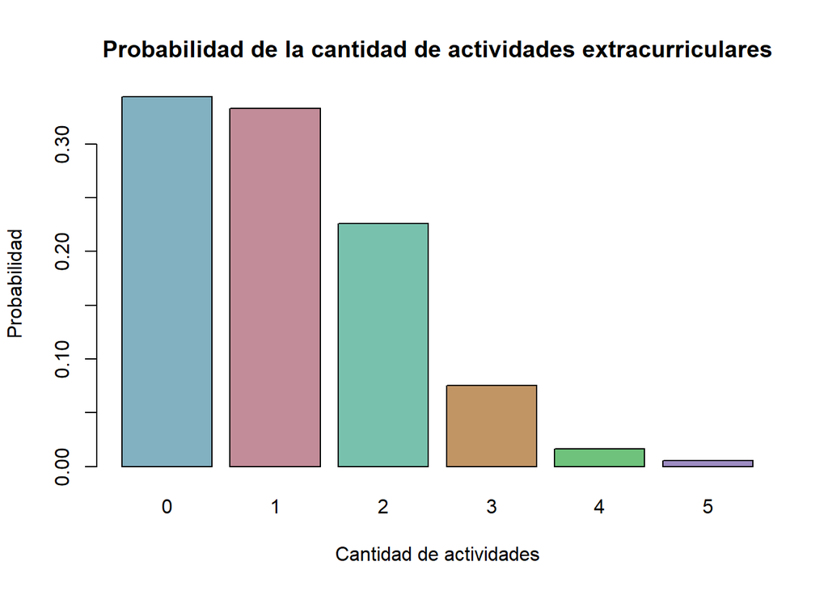

#### 3.3.1.2 Definición de VA y parámetros

X: Cantidad de actividades extracurriculares en la que estudiantes de UTEC del ciclo 2023-1 participan.

X ~ Poisson(λ); donde λ = μ (media)

#### 3.3.1.3 Validación de propiedades

El gráfico parece indicar que la distribución de probabilidades de la variable coincide con una distribución de Poisson. Las principales propiedades de la distribución de Poisson son:

1. La gráfica de probabilidades es asimétrica con probabilidades bajas a la derecha
2. La media es igual o aproximadamente igual a la variación

```
## [1] "Media: 1.102"
```

```
## [1] "Variación: 1.098"
```

Los valores son muy cercanos; por ende, si se podría afirmar que: Varianza ≈ Media.

V(X) = E(X)

3. Los valores altos deben tener probabilidades muy bajas

```
## [1] "Probabilidad de 0 actividades: 0.34"
```

```
## [1] "Probabilidad de 3 actividades: 0.08"
```

```
## [1] "Probabilidad de 5 actividades: 0.01"
```

Mientras aumenta la cantidad de actividades la probabilidad disminuye de manera considerable

#### 3.3.1.4 Ejemplo

Se estíma la probabilidad de que un estudiante realice 3 actividades extracurriculares.

```
## [1] "Probabilidad empírica: 0.075"
```

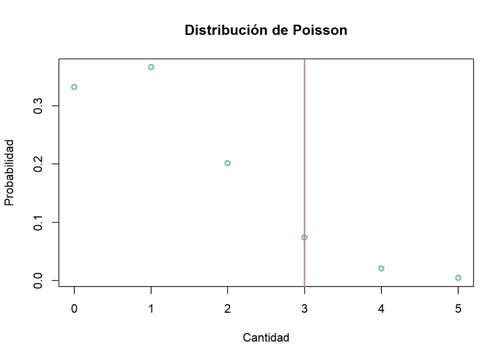

```
## [1] "Probabilidad usando función de distribución de poisson: 0.074"
```

```
## [1] "Esperanza matemática (media): 1.102"
```

```
## [1] "Varianza: 1.098"
```

### 3.3.2 Variable 2

#### 3.3.2.1 Identificación

Variable discreta: Horas invertidas a las actividades extracurriculares en la semana.

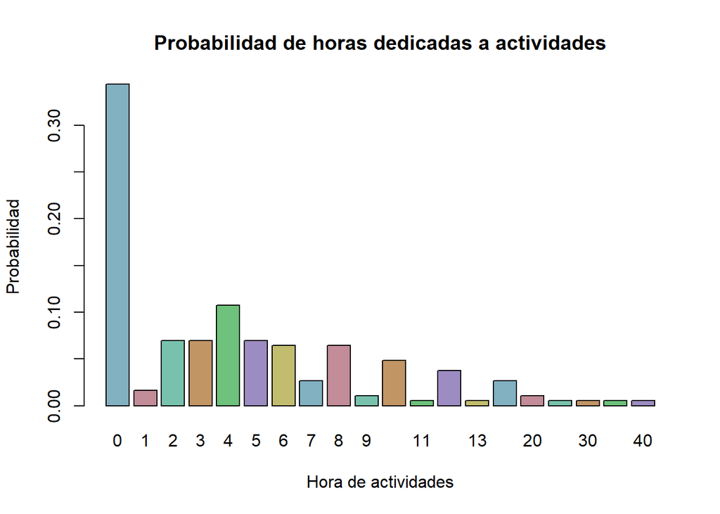

#### 3.3.2.2 Definición de VA y parámetros

X: Cantida de estudiantes de UTEC del ciclo 2023-1 que dedican una hora o más a las actividades extracurriculares a la semana.

X ~ Bin(p,n); donde:

p = P(E); éxito definido como seleccionar un estudiante que dedique una hora o más a las actividades extracurriculares a la semana

n -> tamaño de la muestra

```
## [1] "Probabilidad de éxito: 0.656"
```

```
## [1] "Probabilidad de fallo: 0.344"
```

Definición de parámetros:

```
## [1] "n: 186"
```

```
## [1] "p: 0.656"
```

Gráfico de densidad:

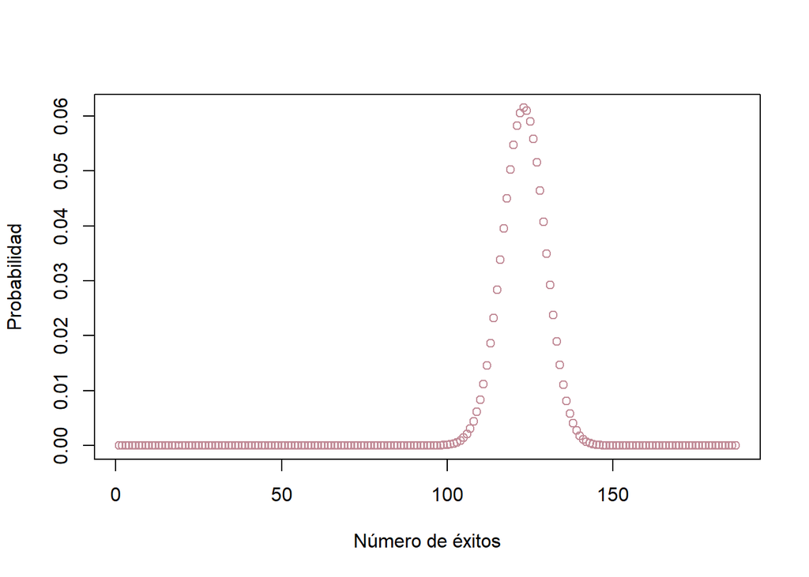

#### 3.3.2.3 Validación de propiedades

Escogemos el modelo de distribución binomial ya que es apropiado cuando tenemos una variable discreta que presenta un número de éxitos en un número fijo de ensayos independientes, donde cada ensayo tiene una probabilidad constante de éxito.

En el caso de las “Horas de actividades extracurriculares” estamos interesados en hallar la probabilidad de que un estudiante tenga éxito (al participar en una horamás en actividades extracurriculares), entonces un modelo binomial puede ser apropiado.

Para que la distribución sea binaria se debe cumplir:

- Número fijo de ensayos

186 observaciones

- Dos únicos eventos, uno de éxito y otro de fallo

Al cumplir con las condiciones se sabe que la distribución es binaria, por lo tanto aplican las siguietnes propiedades:

**Cáluclo de la media - E(X)**

$$E(X) = n*p$$

```
## [1] "Media empírica: 122"
```

```
## [1] "Media teórica: 122"
```

**Cáluclo de la varianza - V(X)**

$$V(X) = n * p * (1 - p)$$

```
## [1] "Varianza empírica: 36.021"
```

```
## [1] "Media teórica: 41.978"
```

**Cáluclo de la desviación**

$$V(X) = [n * p * (1 -
p)]^{1/2}$$

```
## [1] "Desviación empírica: 6.002"
```

```
## [1] "Desviación teórica: 6.479"
```

#### 3.3.2.4 Ejemplo

Si se toma un escenario ficticio donde hay 20 estudiantes y los eventos de éxito y fallo son los mismos vistos anteriormente y la probabilidad de éxito igualmente.

Para eso definimos los siguientes parámetros y graficamos la densidad:

```
## [1] "n: 20"
```

```
## [1] "p: 0.656"
```

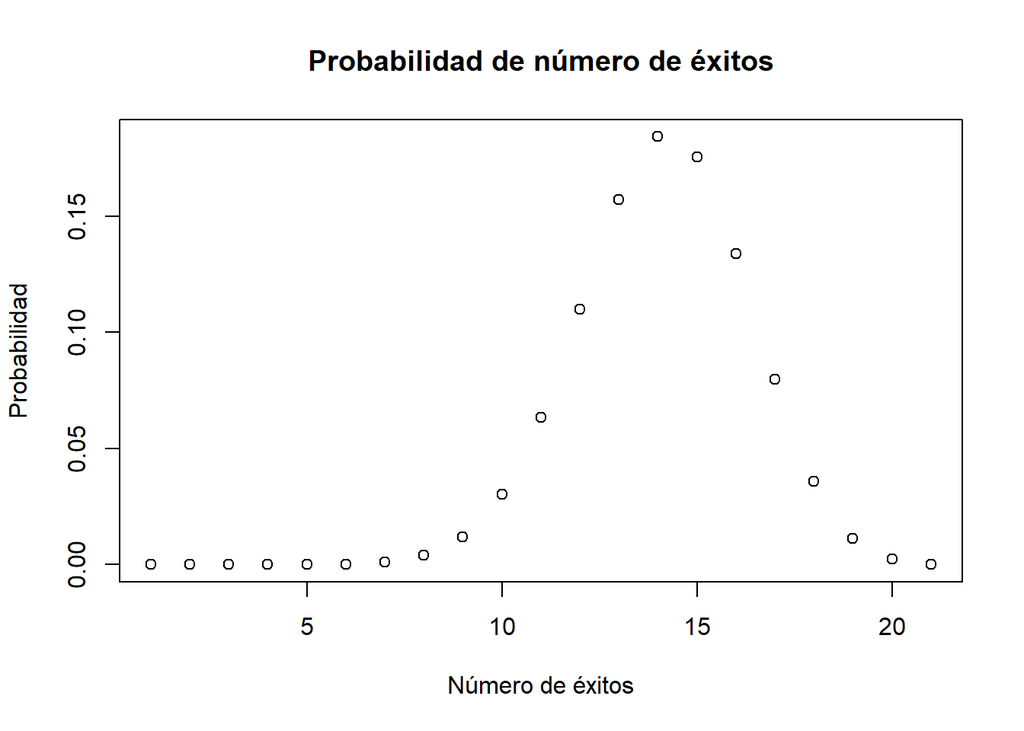

Se quiere calcular la probabilidad de que 13 personas cumplan con el evento de éxito, es decir que inviertan una hora o más en actividades extracurriculares

```
## [1] "Probabilidad: 0.184"
```

## 3.4 Variables continuas

### 3.4.1 Variable 1

#### 3.4.1.1 Identificación

Variable continua: Puntaje del test de habilidades sociales.

Gráfico de densidad de una ‘supuesta normalidad’:

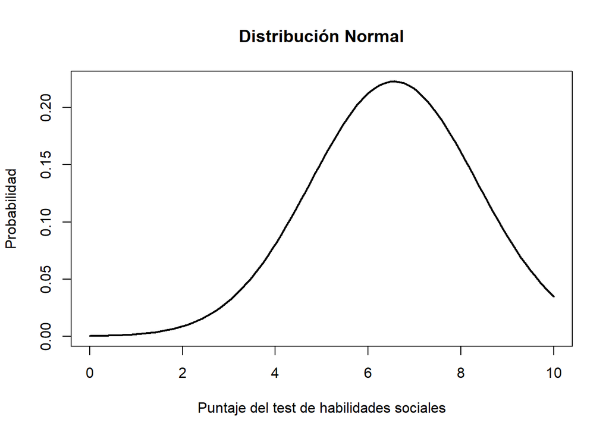

#### 3.4.1.3 Validación de propiedades

Las propiedades de la distribución normal simétrica son:

1. La media es igual o aproximadamente igual a la mediana.

```
## [1] "La media es: 6.655"
```

```
## [1] "La mediana es: 6.75"
```

Los valores son muy cercanos; por ende, si se podría afirmar que: Media ≈ Mediana.

2. La varianza es igual o aproximadamente igual a la desviación estándar.

```
## [1] "La varianza es: 1.748"
```

```
## [1] "La desviación estándar es: 1.79"
```

Los valores son muy cercanos; por ende, si se podría afirmar que: Varianza ≈ Desviación estándar.

3. La esperanza es igual o aproximadamente igual a la media.

```
## [1] "La esperanza es: 6.655"
```

```
## [1] "La media es: 6.553"
```

Los valores son muy cercanos; por ende, si se podría afirmar que: Esperanza ≈ Media.

#### 3.4.1.4 Parámetros de la distribución normal

1. Determinamos la media y desviación estándar de nuestra variable continua:

```
## [1] "µ 6.655"
```

```
## [1] "s 1.748"
```

2. Construimos la expresión: X~N(µ,σ) Donde: X = DF$Test_Social

#### 3.4.1.5 Ejemplo

Tenemos una población de estudiantes de UTEC del ciclo 2023-1 que participan en actividades extracurriculares y estamos interesados en conocer los puntajes del test de habilidades sociales de los estudiantes. La distribución de dicha variable sigue una distribución normal con una media de 6.637769 y una desviación estándar de 1.744922. Nos interesa calcular la probabilidad acumulada de que un estudiante seleccionado al azar tenga un puntaje inferior a 3.33 puntos en dicho test, ya que si un alumno presenta un valor en ese rango significa que las interacciones sociales suelen producirle malestar y no disfruta de ella.

```
## [1] "Probabilidad: 0.029"
```

### 3.4.2 Variable 2

#### 3.4.2.1 Identificación

Variable continua: Puntaje del test de liderazgo y trabajo en equipo.

Gráfico de densidad de una ‘supuesta normalidad’:

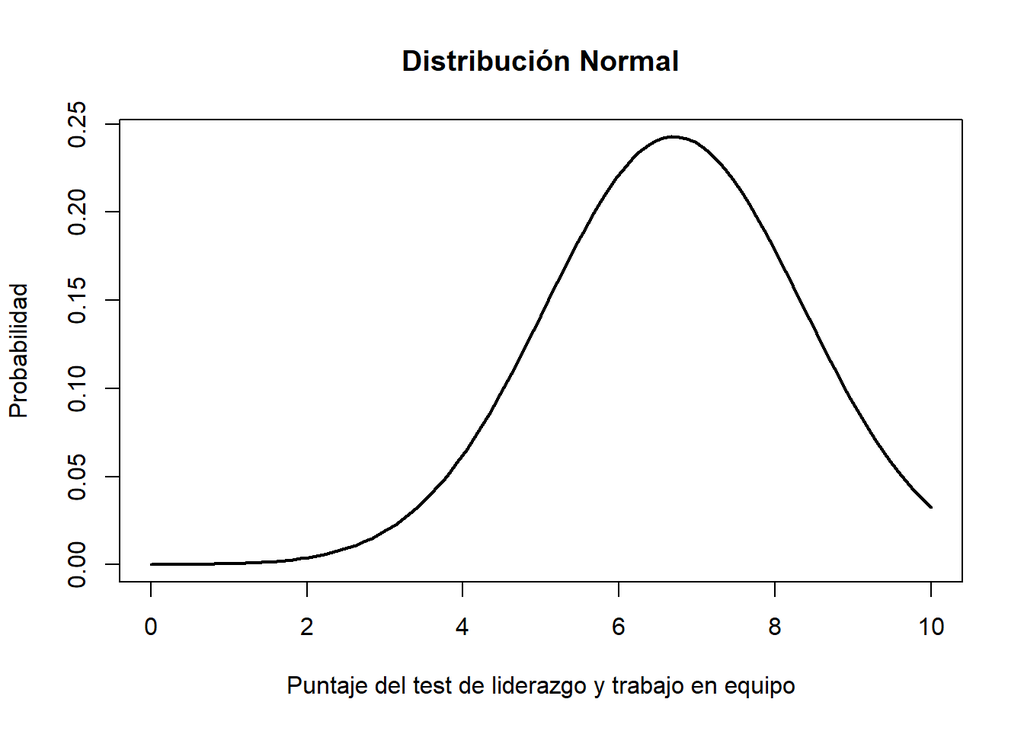

#### 3.4.2.3 Validación de variable continua

Las propiedades de la distribución normal simétrica son:

1. La media es igual o aproximadamente igual a la mediana.

```
## [1] "La media es: 6.782"
```

```
## [1] "La mediana es: 6.75"
```

Los valores son muy cercanos; por ende, si se podría afirmar que: Media ≈ Mediana.

2. La varianza es igual o aproximadamente igual a la desviación estándar.

```
## [1] "La varianza es: 1.57"
```

```
## [1] "La desviación estándar es: 1.643"
```

Los valores son muy cercanos; por ende, si se podría afirmar que: Varianza ≈ Desviación estándar.

3. La esperanza es igual o aproximadamente igual a la media.

```
## [1] "La esperanza es: 6.782"
```

```
## [1] "La media es: 6.707"
```

Los valores son muy cercanos; por ende, si se podría afirmar que: Esperanza ≈ Media.

#### 3.4.2.4 Parámetros de la distribución normal

1. Determinamos la media y desviación estándar de nuestra variable continua:

```
## [1] "µ 6.782"
```

```
## [1] "s 1.57"
```

2. Construimos la expresión: X~N(µ,σ) Donde: X = DF$Test_Liderazgo

#### 3.4.2.5 Ejemplo

Tenemos una población de estudiantes de UTEC del ciclo 2023-1 que participan en actividades extracurriculares y estamos interesados en conocer los puntajes del test de liderazgo y trabajo en equipo de los estudiantes. La distribución de dicha variable sigue una distribución normal con una media de 6.780413 y una desviación estándar de 1.576117. Nos interesa calcular la probabilidad acumulada de que un estudiante seleccionado al azar tenga un puntaje inferior a 7 puntos en dicho test, ya que ellos necesitarían ayuda para vencer sus inseguridades y así florecer el potencial de líder que posee.

```
## [1] "Probabilidad: 0.555"
```

# 4 Conclusiones

- **Conclusión 1:** La participación en actividades extracurriculares afecta positivamente a la autopercepción del desarrollo personal de los estudiantes de la UTEC en el ciclo 2023-1. Más especificamente con la satisfacción que sienten con su participación en actividades extracurriculares.
- **Conclusión 2:** La participación en actividades extracurriculares no afecta al rendimiento académico de los estudiantes de la UTEC en el ciclo 2023-1. Esto se puede comprobar al observar que la cantidad de horas dedicadas a las actividades extracurriculares no afecta a la cantidad de horas dedicadas al estudio.
- **Conclusión 3:** La participación en actividades extracurriculares afecta positivamente el desarrollo de habilidades blandas de los estudiantes de la UTEC en el ciclo 2023-1. Esto se puede comprobar con que el puntaje de los tests de habilidades sociales es mayor entre quienes participan en actividades.